# <sub>Beave</sub>R Tutorial

Compiled by Grace Klinges

PhD Student, Oregon State University

Department of Microbiology, Vega Thurber Lab

klingesj@oregonstate.edu

March 2019

# What is R?

R is both a programming language and an environment designed for **data manipulation, analysis, and visualization**. One of the great benefits of R compared to classical statistics programs (Stata, SPSS, SAS and even MATLAB) is its flexibility. R is free and source code is open-source, unlike the “black box” model that other statistical software follows. This has encouraged the development of over 10,000 packages available through CRAN alone (i.e. excluding packages through BioConductor, Github, commercial R packages, and what is certainly an uncountable number of unpublished packages). Basically any analysis you would want to run has already been implemented by someone else and released as a package.

On top of that, R is a relatively simple language derived from S through which you could define any new function or analysis yourself. While many other statistical tools are point-and-click GUIs (graphical user interfaces) that can be initially more accessible, the output from R is more **transparent and replicable**, as R code can be saved, shared, and published for use in other studies. R can be run on Linux, MacOS, and Windows.

A working knowledge of R is essential for many types of biological data analysis, and we encourage you to keep exploring if this tutorial is your first introduction to R. There are some great intermediate and advanced tutorials on R that I will include under **Other Resources** at the end of this tutorial.

# Downloading R/RStudio

For this tutorial, you will need **both R and RStudio**. R must be downloaded through the **“Comprehensive R Archive Network” (CRAN)**, which is a collection of mirrored (identical) sites holding the latest official R releases, copies of current source code as gzipped and bzipped tar files, contributed extensions and their code, prebuilt binaries for different operating systems, and documentation and bug tracking for R.

## R Download

The CRAN master site is hosted through the Wirtschaftsuniversität Wien in Austria, and this site is mirrored to many other sites throughout the world. You should download R through the mirror closest to you geographically to equally distribute network load on the mirrors. Oregon State hosts two mirrors:

https://ftp.osuosl.org/pub/cran/

http://ftp.osuosl.org/pub/cran/

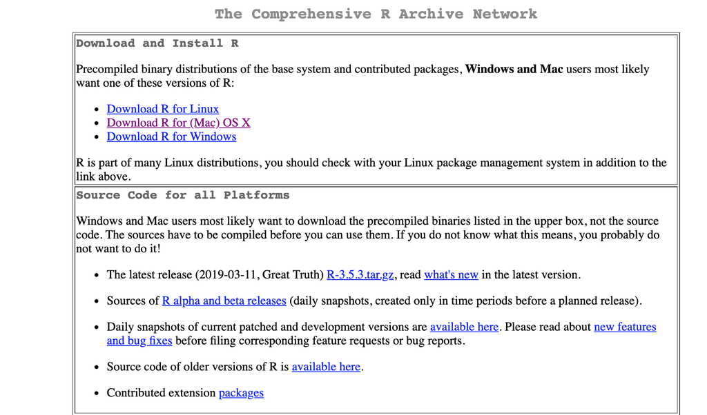

Select your operating system, and go down to “Latest Release” and download the precompiled source binary (computer readable). As of the day I’m writing this tutorial, the current version is R-3.5.2, so I would click on R-3.5.2.pkg.

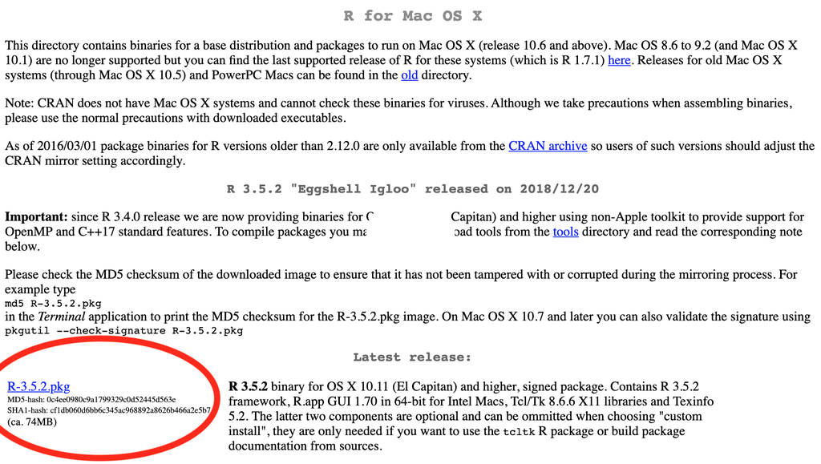

## RStudio Download

You will also need to download [RStudio](https://www.rstudio.com/products/rstudio/download/#download,%20%7Btarget=%22_blank%22%7D), which is a **free, open source IDE** (integrated development environment) for R that allows the user to clearly view graphs, data tables, R code, and output all at the same time. This program requires R to already be installed locally.

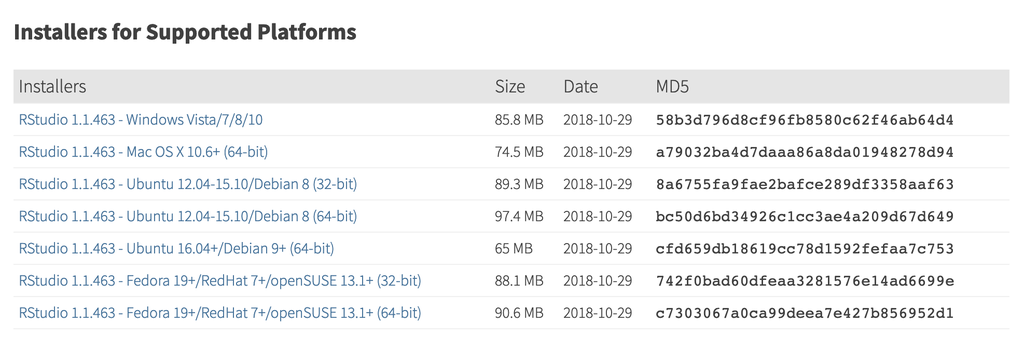

## Getting around RStudio

R studio has a **four-panel interface**, which better manages several R windows for typing commands, storing scripts, viewing command histories, viewing plots and more. You will end up doing most of your work in either the top left panel or the bottom left.

The **top left** panel is both the code editor, which allows you to write and run scripts with multiple lines of R code, and a file viewer, allowing you to view imported data and created objects. Note that if you don’t have an R script or any files open, this panel will be collapsed and the bottom left panel will fill the screen.

The **bottom left** panel has tabs with an interactive R console and a command line terminal. Any code run from the top left panel will also show up in the console as it runs. We will be working in the Console for this tutorial, so whever I have code written in here, you can paste it into the Console tab and hit enter to run it.

The **top right** panel shows your environment and your recent command history. Your environment consists of any objects in memory for a given project. In your command history, you can click on individual or multiple lines of code to send them to the console or code editor. The Connections tab shows any R extensions available on your system.

Finally, the **bottom right** panel shows your installed packages, organization of files in the directory assigned to the current workspace, a panel where data visualizations will be displayed (with arrows to navigate through previous plots, and options to export plots). This is also where any help files will show up when requested from the console.

It’s worth mentioning that the organization of these panes can be changed in *Preferences/Pane Layout*.

[figure not shown]

My RStudio layout. Yours may look a bit different based on your selected preferences.

# RStudio Workspace

What is the R workspace? This is the **current R working environment and any objects** that you are using (vectors, matrices, files, data frames, classes, lists, functions…etc). You can choose to save your workspace and reload it the next time you start R. You will probably want to save your projects in different directories (folders), or save associated projects in nested folders. If you have previous command line experience, you will find some of the basic R syntax to be the same (depending on the shell you normally use), while some functions will execute the same commands you are used to under a different name.

Try to do the commands in this tutorial as you go through it, it will help solidify the concepts and also double check that your R install is working properly :)

## Navigation and Organization Commands

`getwd()` prints current working directory (CWD) - this is the folder on your computer that R is saving data to.

`setwd()` changes the location of your working directory. Try `setwd("Desktop")`. You can also click *Session/Set Working Directory/Choose Directory…* in the Toolbar.

`list.files()` will list all files in the directory you are working in.

`ls()` or `objects()` lists objects in current workspace

`rm()` or `remove()`removes objects

`View()` lets you view an object you’ve created or imported. Double clicking on an object in the Environment tab will accomplish the same thing.

## RStudio Projects

RStudio is designed to help you organize your data analysis into **projects**.This allows you to save all the code and files from a group of analyses onto a directory on your computer. This way, R scripts associated with the project can be entirely **self-contained**: a script run from inside the project directory will have everything it needs, and won’t touch any files outside that directory. Since the project is self-contained, the entire directory can be moved anywhere on your computer (or another person’s computer) and will still work.

You can create a **new project space** by going to File/New Project, and from there you can save and open the project like it was a document.

[figure not shown]

Using projects allows us to avoid using `setwd()` at the beginning of a script to tell the script where to work. While `setwd()` will work well on your computer, any paths you set will almost certainly not work for anyone else who wants to run the script (including yourself, two years from now when you’ve cleared out old folders you didn’t think you needed). To make it work, the recipient of your script would have to change the paths to reflect where the project is on their computer.

Avoid this snafu entirely by keeping all relevant material to a project in the project directory. If you have multiple subdirectories within a project, make sure the top-level folder is named something descriptive of the project so the user of the project knows to launch R from this folder. This is where RStudio will save the `.Rproj` file that stores all the data for a project.

See “Other Resources” at the end of this tutorial for more best practices tips. Using good R etiquette as early as possible avoids a mad rush to clean up your scripts when someone asks to see them!

Start using R Projects as soon as possible. In fact, making a project for this tutorial wouldn’t be a bad idea: that way, if you decide to return to this tutorial later, you’ll have everything you need in one place.

Let’s make a **new project** called *R Tutorial*. I’ll let you decide where you want to put the directory for this project on your computer, but I’d suggest a new directory rather than working in an existing directory. Once you’ve opened that project, download Pets_data.csv and pet_stats.csv and move them to that directory. We will be using them later in this tutorial.

## Built in help functions

R has a built-in, comprehensive **help system**. Here are some useful commands.

`help.start()` –> general help

`help("function")` –> help about a given function

`?function` –> same as above

`apropos("string")` –> list all functions containing a given string

`example("function")` –> show an example of function

`RSiteSearch("string")` –> searches the R website for any function or string

R also has a handy function called **vignettes**, which are interactive manuals written in rmarkdown that show up in the “Help” panel.

`vignette()` –> lists all available vignettes for packages you have installed.

`vignette("function")` –> provides the vignette for a given function.

If any of the functions we use in this tutorial get confusing, just type in ? and the name of the function into the R console to get some help on using that function.

# Basic R functions

Before we get into the most basic R functins, some **essential R shortcuts**. The Tab button will attempt to autocomplete anything you are typing in the console or script editor, autofilling functions, objects, or file names.

In the interactive console, hitting the **up arrow** will show you your most recent command. Continuing to hit the up arrow will scroll through recent commands. Hitting *either* **Ctrl** or **Cmd** *and* the **up** arrow will show you a popup of recent commands you have executed, from which you can select a command and hit enter to run it. You can also see your command history in the History tab of the upper right panel, or running `history()` on the console.

In the code editor panel (top left), hitting **Ctrl** and **Enter** will **execute the current line of code** from the editor.

To get familiar with how the interactive R console works, let’s try some **basic math** in the lower left panel. R can be used as a calculator, using `+`, `-` ,`*` (for multiplication) and `/` (for division)

```r
2+2
```

```
## [1] 4
```

The [1] in front of the answer tells us that the answer had only 1 value. Eventually we will start seeing results with more than one value.

You can use R to conduct more complicated arithmetic, such as trigonometry, exponents, square roots, and logarithms.

```r
sqrt(49)
```

```
## [1] 7
```

```r
7^2
```

```
## [1] 49
```

```r
cos(pi)
```

```
## [1] -1
```

## R objects

An **object** in R is a data structure having some attributes on which we can use methods. Anything you can work with in R is an object.

Create **new objects** in R using “<-”. The syntax of this will always be the same; think **“object gets value”** to remember the order.

Let’s start with variables, which contain just one value.

```r
example_variable <- 9
```

A good convention is to separate words with an “_" as spaces are not allowed. It’s helpful to use delimitors purposefully, such as denoting the date of a file with dashes and appending the sample name with underscores; e.g. 2019-01-01_sample_01.txt, 2019-01-01_sample_02.txt.

```r
this_is_easy
this.is.fine.too
thisishardtoread
this_name_is_too_long_and_inconvenient
```

Objects with names more than one word long are a great opportunity to use R’s tab completion function. Once you’ve named an object, you can type the start of its name and hit “Tab,” and R will autocomplete the function you are typing out from a popup list. If you don’t want the first suggested function, just click on another function on the list that pops up as you type.

Another important note: R is **case-sensitive**. R may be pretty magical, but it can’t read your mind and you must be precise in the instructions you give it.

```r
This_is_easy
```

```
## Error in eval(expr, envir, enclos): object 'This_is_easy' not found
```

Ok, let’s create a new variable. You can do math with variables just as we did with numbers in the console.

```r
new_number <- 25
new_number
```

```
## [1] 25
```

```r
sqrt(new_number)
```

```
## [1] 5
```

Writing out <- can be a pain. On a Mac, type “Option -”, on a PC type “Alt -”. [**Here**](https://support.rstudio.com/hc/en-us/articles/200711853-Keyboard-Shortcuts) is a list of other handy RStudio keyboard shortcuts.

## Vectors

Vectors are another basic data structure in R, and contain elements of the same type. Possible data types for vectors: logical (also called boolean), integer, double, character, complex, or raw. R provides some basic functions to explore the features of vectors and other objects.

`typeof()` - what is the R internal type of the object? Running this command on a vector will produce one of the six data types listed above. Running this on other objects might produce “list”, “NULL”, “environment”, or “S4” for formal classes.

`class()`- what kind of object is it (higher level than `typeof()`)?

`length()` - how long is it? What about two dimensional objects?

`attributes()` - does it have any metadata?

To **build vectors**, you will need to specify their content with `c()`.

```r
x <- c(1,2,3,4,5)
x
```

```
## [1] 1 2 3 4 5
```

R can usually guess the appropriate storage mode for the vector. TRUE and FALSE will create a logical vector, quoted text will create a character vector.

```r
y <- c(TRUE, TRUE, FALSE, FALSE)
length(y)
```

```
## [1] 4
```

```r
typeof(y)
```

```
## [1] "logical"
```

To **add elements** to a vector, just use `c()` as you did to build the vector. You are essentially overwriting the existing vector, so you’ll need to specify you want to add the current elements of the vector by naming it.

```r
x <- c(x, 19)
x
```

```
## [1]  1  2  3  4  5 19
```

You can also **add a sequence** of numbers to a vector, and **look up** the content of a vector at a specific element.

```r
numbers <- 1:100
numbers[96:98] ## Brackets indicate the position within the vector we want to examine (called the index). Specify just one location or use a colon to look up the contents at a range of locations.
```

```
## [1] 96 97 98
```

You can **perform arithmetic** on a vector much like you can on a variable, or even add a variable to a vector (this will add the variable to all elements in the vector).

```r
numbers - 1 ## Note that here we start to see other elements being labeled besides [1].
```

```
##   [1]  0  1  2  3  4  5  6  7  8  9 10 11 12 13 14 15 16 17 18 19 20 21 22
##  [24] 23 24 25 26 27 28 29 30 31 32 33 34 35 36 37 38 39 40 41 42 43 44 45
##  [47] 46 47 48 49 50 51 52 53 54 55 56 57 58 59 60 61 62 63 64 65 66 67 68
##  [70] 69 70 71 72 73 74 75 76 77 78 79 80 81 82 83 84 85 86 87 88 89 90 91
##  [93] 92 93 94 95 96 97 98 99
```

```r
## [24] tells us that that line starts with the 24th value of the vector.

new_number
```

```
## [1] 25
```

```r
new_number + numbers
```

```
##   [1]  26  27  28  29  30  31  32  33  34  35  36  37  38  39  40  41  42
##  [18]  43  44  45  46  47  48  49  50  51  52  53  54  55  56  57  58  59
##  [35]  60  61  62  63  64  65  66  67  68  69  70  71  72  73  74  75  76
##  [52]  77  78  79  80  81  82  83  84  85  86  87  88  89  90  91  92  93
##  [69]  94  95  96  97  98  99 100 101 102 103 104 105 106 107 108 109 110
##  [86] 111 112 113 114 115 116 117 118 119 120 121 122 123 124 125
```

All elements in a vector must be the **same data type**, or R will force all values to be the same.

```r
num <- c(1, 2, "three")
num
```

```
## [1] "1"     "2"     "three"
```

```r
hmm <- c("TRUE", "FALSE", 3)
hmm
```

```
## [1] "TRUE"  "FALSE" "3"
```

## Matrices

Another essential R data structure is matrices, which are **vectors with dimensions** provided by the number of rows and columns.

```r
m <- matrix(nrow = 2, ncol = 3)
m
```

```
##      [,1] [,2] [,3]
## [1,]   NA   NA   NA
## [2,]   NA   NA   NA
```

```r
dim(m) ## Reports dimensions as rows x columns.
```

```
## [1] 2 3
```

```r
m2 <- matrix(c(1:3))
m2
```

```
##      [,1]
## [1,]    1
## [2,]    2
## [3,]    3
```

```r
matrix1 <- matrix(1:6, nrow = 2, ncol = 3) ## This will fill a matrix of dimensions 2 x 3 with the numbers 1 through 6. Note that R fills the matrix by column first.
matrix1
```

```
##      [,1] [,2] [,3]
## [1,]    1    3    5
## [2,]    2    4    6
```

```r
matrix2 <- matrix(1:6, nrow = 2, ncol = 3, byrow = TRUE) ## Specify 'byrow = TRUE' to ask R to fill rows first.
matrix2
```

```
##      [,1] [,2] [,3]
## [1,]    1    2    3
## [2,]    4    5    6
```

```r
cbind(num, hmm) ## cbind() will bind vectors into columns of a matrix. rbind() will bind vectors as rows.
```

```
##      num     hmm
## [1,] "1"     "TRUE"
## [2,] "2"     "FALSE"
## [3,] "three" "3"
```

```r
rbind(num, hmm)
```

```
##     [,1]   [,2]    [,3]
## num "1"    "2"     "three"
## hmm "TRUE" "FALSE" "3"
```

Note that to bind together vectors, they must be the **same length** (check with `length()`) or weird things will start happening. In this case, a matrix was sucessfully generated, but because num was longer than the number of integers in range (3:4), R decided to repeat the vector to match the number of rows in the first column. Luckily, it warns us to let us know something sketchy is happening.

```r
cbind(num, 3:4)
```

```
## Warning in cbind(num, 3:4): number of rows of result is not a multiple of
## vector length (arg 2)
```

```
##      num
## [1,] "1"     "3"
## [2,] "2"     "4"
## [3,] "three" "3"
```

The command `as.matrix()` will allow you to express objects containing the same data type as a matrix. The parameter `mode=''` can be provided to specify the data type, e.g. ‘numeric’, ‘character’ or ‘any’.

## Lists

Lists are like vectors, except that members of a list are not required to have the same data type. Lists can be created using `list()` or express other objects as lists using `as.list()`.

```r
x <- list(10, "Shiela", TRUE)

## Retrieve contents of list at a given element using double square brackets [[]]
x[[2]]
```

```
## [1] "Shiela"
```

```r
x <- 1:6
x <- as.list(x)
x
```

```
## [[1]]
## [1] 1
##
## [[2]]
## [1] 2
##
## [[3]]
## [1] 3
##
## [[4]]
## [1] 4
##
## [[5]]
## [1] 5
##
## [[6]]
## [1] 6
```

You can name elements of a list:

```r
sample_list <- c("Sample1", "Sample2", "Sample3", "Sample4", "Sample5", "Sample6")

named_list <- list("Title" = "Sample_data", "Sample Names" = sample_list, Data = rnorm(1:6))
named_list
```

```
## $Title
## [1] "Sample_data"
##
## $`Sample Names`
## [1] "Sample1" "Sample2" "Sample3" "Sample4" "Sample5" "Sample6"
##
## $Data
## [1]  1.0004927  0.9353010 -0.4757987  0.8765802  1.7922122 -0.3862633
```

```r
names(named_list)
```

```
## [1] "Title"        "Sample Names" "Data"
```

If elements of a list are named, they can be accessed using `$`.

```r
named_list$Data
```

```
## [1]  1.0004927  0.9353010 -0.4757987  0.8765802  1.7922122 -0.3862633
```

## Data Frames

A data frame is a special type of list where every element of the list must have the same length (or weird things happen, like with matrices). While matrices can only store data of one type, data frames are much more flexible and can contain multiple types. Basically, data frames are to lists what matrices are to vectors. Data frames are the fundamental data structure used by R and its packages.

Data frames are created using `data.frame()` or by importing data from outside R using functions such as `read.csv()` and `read.table()`. We can assign attributes to a data frame with functions such as `rownames()` and `colnames()`. We can convert a data frame to a matrix (provided all data are the same data type) using `data.matrix()` or `as.matrix()`.

We can name elements of a data frame using the same conventions as used for lists.

```r
df <- data.frame(sample_names = letters[1:10], Height = 1:10, Weight = 11:20)
df
```

```
##    sample_names Height Weight
## 1             a      1     11
## 2             b      2     12
## 3             c      3     13
## 4             d      4     14
## 5             e      5     15
## 6             f      6     16
## 7             g      7     17
## 8             h      8     18
## 9             i      9     19
## 10            j     10     20
```

Two important functions you will want to know to understand a data frame are `dim()` and `str()`. `dim()` tells you the dimmensions (rows x columns) of your data frame, while `str()` tells you what the structure is. You can examine the structure of any R object and it will tell you what type of object it is and what data it holds, while you can only retrieve the dimensions of a 2-dimensional object (e.g. matrices or data frames).

```r
dim(df) ## Shows us that data frame df has 10 rows and 3 columns. Checking the dimensions of an object can be a good sanity check to make sure R is reading your data correctly.
```

```
## [1] 10  3
```

```r
str(df) ## Tells us a little more about df: that df is a data frame, what the names of our columns are and what type of data each column holds. "Factor" tells us that our sample_names column holds categorical data, while "int" tells us that our height and weight columns hold integer data.
```

```
## 'data.frame':    10 obs. of  3 variables:
##  $ sample_names: Factor w/ 10 levels "a","b","c","d",..: 1 2 3 4 5 6 7 8 9 10
##  $ Height      : int  1 2 3 4 5 6 7 8 9 10
##  $ Weight      : int  11 12 13 14 15 16 17 18 19 20
```